# Imbalanced class - sampling techniques

#### load the data

```r
library(ROSE)
data(hacide)
str(hacide.train)
```

```
## 'data.frame':    1000 obs. of  3 variables:
##  $ cls: Factor w/ 2 levels "0","1": 1 1 1 1 1 1 1 1 1 1 ...
##  $ x1 : num  0.2008 0.0166 0.2287 0.1264 0.6008 ...
##  $ x2 : num  0.678 1.5766 -0.5595 -0.0938 -0.2984 ...
```

#### check classes distribution

```r
table(hacide.train$cls)
```

```
##
##   0   1
## 980  20
```

```r
prop.table(table(hacide.train$cls))
```

```
##
##    0    1
## 0.98 0.02
```

#### using decision tree on imbalanced classes

```r
library(rpart)
treeimb <- rpart(cls ~ ., data = hacide.train)
pred.treeimb <- predict(treeimb, newdata = hacide.test)
head(pred.treeimb)
```

```
##           0          1
## 1 0.9898888 0.01011122
## 2 0.9898888 0.01011122
## 3 0.9898888 0.01011122
## 4 0.9898888 0.01011122
## 5 0.9898888 0.01011122
## 6 0.9898888 0.01011122
```

#### error measures

```r
library(caret)
library(e1071)

#using threshold of 0.5
glm.default=rep("0",length(pred.treeimb[,2]))
glm.default[pred.treeimb[,2]>0.5] <- "1"

confusionMatrix(glm.default,hacide.test$cls,positive = "1")
```

```
## Confusion Matrix and Statistics
##
##           Reference
## Prediction   0   1
##          0 245   4
##          1   0   1
##
##                Accuracy : 0.984
##                  95% CI : (0.9595, 0.9956)
##     No Information Rate : 0.98
##     P-Value [Acc > NIR] : 0.4387
##
##                   Kappa : 0.3289
##  Mcnemar's Test P-Value : 0.1336
##
##             Sensitivity : 0.2000
##             Specificity : 1.0000
##          Pos Pred Value : 1.0000
##          Neg Pred Value : 0.9839
##              Prevalence : 0.0200
##          Detection Rate : 0.0040
##    Detection Prevalence : 0.0040
##       Balanced Accuracy : 0.6000
##
##        'Positive' Class : 1
##
```

```r
#Metrics to evaluate a classifier accuracy in imbalanced learning
accuracy.meas(hacide.test$cls, pred.treeimb[,2])
```

```
##
## Call:
## accuracy.meas(response = hacide.test$cls, predicted = pred.treeimb[,
##     2])
##
## Examples are labelled as positive when predicted is greater than 0.5
##
## precision: 1.000
## recall: 0.200
## F: 0.167
```

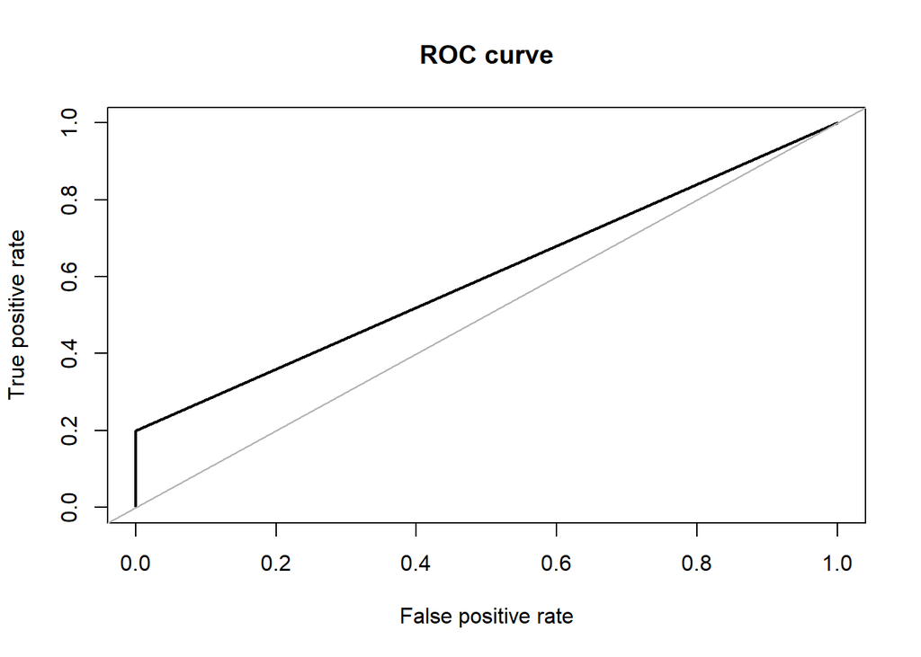

```
## Area under the curve (AUC): 0.600
```

```r
roc.curve(hacide.test$cls, pred.treeimb[,2], plotit = T)
```

- AUC = 0.60 is a terribly low score. Therefore, it is necessary to balance the data before applying a machine learning algorithm.

#### over sampling

```r
data_balanced_over <- ovun.sample(cls ~ ., data = hacide.train, method = "over",N = 1960)$data

table(data_balanced_over$cls)
```

```
##
##   0   1
## 980 980
```

- In the code above, method over instructs the algorithm to perform over sampling. N refers to number of observations in the resulting balanced set. In this case, originally we had 980 negative observations. So, I instructed this line of code to over sample minority class until it reaches 980 and the total data set comprises of 1960 samples.

#### under sampling

```r
data_balanced_under <- ovun.sample(cls ~ ., data = hacide.train, method = "under",N = 40,seed=1)$data

table(data_balanced_under$cls)
```

```
##
##  0  1
## 20 20
```

- In the code above, method over instructs the algorithm to perform under sampling. N refers to number of observations in the resulting balanced set. In this case, originally we had 20 positive observations. So, I instructed this line of code to under sample majority class until it reaches 20 and the total data set comprises of 40 samples.

#### Both under and over sampling

```r
data_balanced_both <- ovun.sample(cls ~ ., data = hacide.train, method = "both",N = 1000,seed=1)$data

table(data_balanced_both$cls)
```

```
##
##   0   1
## 520 480
```

- The data generated from oversampling have expected amount of repeated observations.
- Data generated from undersampling is deprived of important information from the original data. This leads to inaccuracies in the resulting performance.
- To encounter these issues, ROSE helps us to generate data synthetically as well.
- The data generated using ROSE is considered to provide better estimate of original data

#### ROSE

```r
data.rose <- ROSE(cls ~ ., data = hacide.train, seed = 1)$data
table(data.rose$cls)
```

```
##
##   0   1
## 520 480
```

#### build decision tree models

```r
tree.rose <- rpart(cls ~ ., data = data.rose)
tree.over <- rpart(cls ~ ., data = data_balanced_over)
tree.under <- rpart(cls ~ ., data = data_balanced_under)
tree.both <- rpart(cls ~ ., data = data_balanced_both)
```

#### make predictions on unseen data

```r
pred.tree.rose <- predict(tree.rose, newdata = hacide.test)
pred.tree.over <- predict(tree.over, newdata = hacide.test)
pred.tree.under <- predict(tree.under, newdata = hacide.test)
pred.tree.both <- predict(tree.both, newdata = hacide.test)
```

#### evaluating the models using roc curve

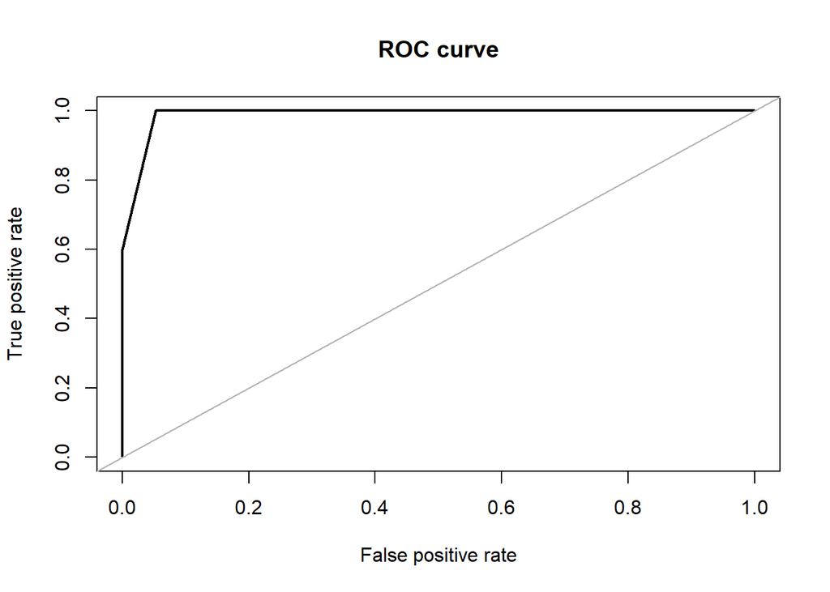

```
## Area under the curve (AUC): 0.989
```

```r
#AUC ROSE
roc.curve(hacide.test$cls, pred.tree.rose[,2])
```

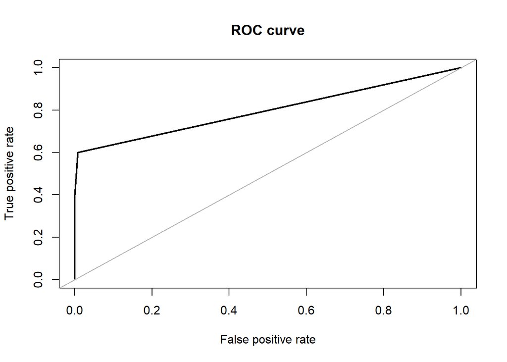

```
## Area under the curve (AUC): 0.798
```

```r
#AUC Oversampling
roc.curve(hacide.test$cls, pred.tree.over[,2])
```

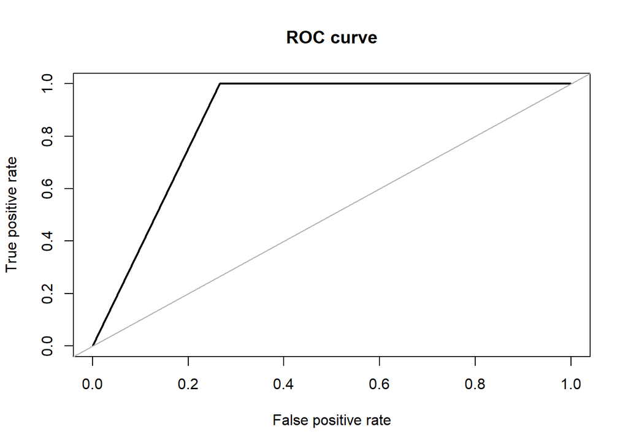

```
## Area under the curve (AUC): 0.867
```

```r
#AUC Undersampling
roc.curve(hacide.test$cls, pred.tree.under[,2])
```

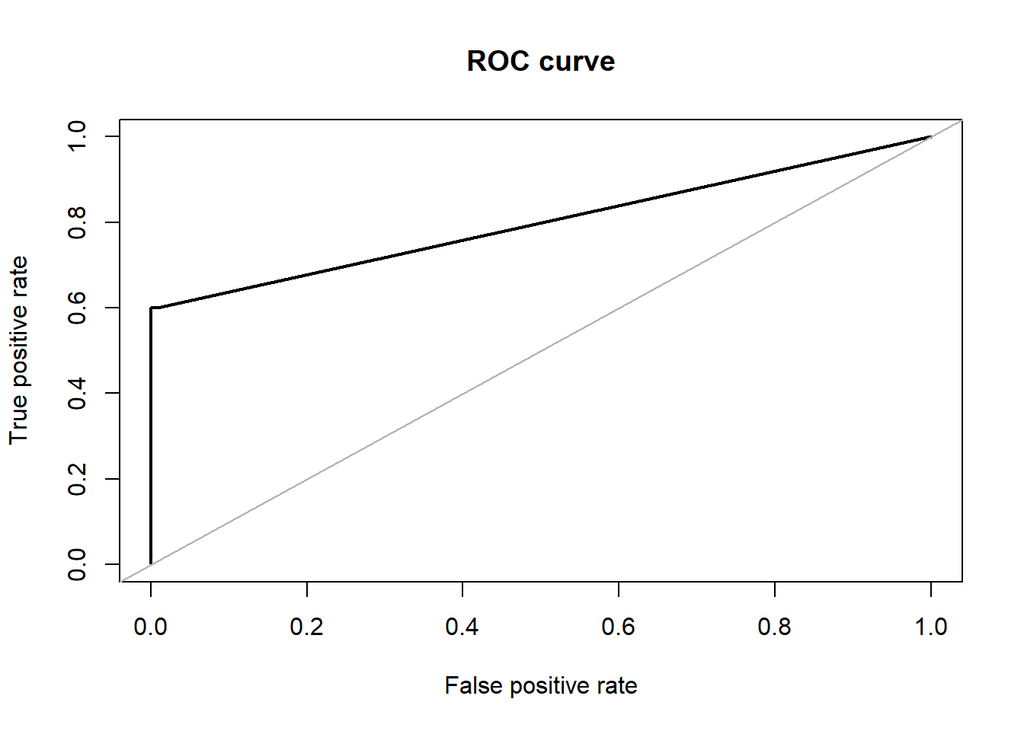

```
## Area under the curve (AUC): 0.798
```

```r
#AUC Both
roc.curve(hacide.test$cls, pred.tree.both[,2])
```

- Hence, we get the highest accuracy from data obtained using ROSE algorithm.
- We see that the data generated using synthetic methods result in high accuracy as compared to sampling methods.
- This technique combined with a more robust algorithm (random forest, boosting) can lead to exceptionally high accuracy

#### ROSE holdout

```r
ROSE.holdout <- ROSE.eval(cls ~ ., data = hacide.train, learner = rpart, method.assess = "holdout", extr.pred = function(obj)obj[,2], seed = 1)

ROSE.holdout
```

```
##
## Call:
## ROSE.eval(formula = cls ~ ., data = hacide.train, learner = rpart,
##     extr.pred = function(obj) obj[, 2], method.assess = "holdout",
##     seed = 1)
##
## Holdout estimate of auc: 0.985
```

- We see that our accuracy retains at ~ 0.98 and shows that our predictions aren’t suffering from high variance

#### ROSE LKOCV

```r
ROSE.LKOCV <- ROSE.eval(cls ~ ., data = hacide.train, learner = rpart, method.assess = "LKOCV", extr.pred = function(obj)obj[,2], seed = 1,K=5)

ROSE.LKOCV
```

```
##
## Call:
## ROSE.eval(formula = cls ~ ., data = hacide.train, learner = rpart,
##     extr.pred = function(obj) obj[, 2], method.assess = "LKOCV",
##     K = 5, seed = 1)
##
## Leave K out cross-validation estimate of auc: 0.973
```

- We see that our accuracy is ~ 0.97

#### ROSE BOOT

```r
ROSE.BOOT <- ROSE.eval(cls ~ ., data = hacide.train, learner = rpart, method.assess = "BOOT", extr.pred = function(obj)obj[,2], seed = 1,B=100)

ROSE.BOOT
```

```
##
## Call:
## ROSE.eval(formula = cls ~ ., data = hacide.train, learner = rpart,
##     extr.pred = function(obj) obj[, 2], method.assess = "BOOT",
##     B = 100, seed = 1)
##
## Bootstrap estimate of auc on 100 samples:
##  0.985 0.981 0.979 0.989 0.978 0.988 0.984 0.985 0.983 0.981 0.984 0.974 0.980 0.991 0.980 0.982 0.981 0.986 0.988 0.984 0.986 0.928 0.987 0.985 0.982 0.982 0.978 0.974 0.986 0.980 0.980 0.986 0.977 0.987 0.984 0.981 0.973 0.987 0.989 0.987 0.977 0.978 0.986 0.986 0.988 0.986 0.981 0.980 0.985 0.…
```

```r
mean(ROSE.BOOT$acc)
```

```
## [1] 0.9811296
```

- We see that our accuracy is ~ 0.98

#### SMOTE

```r
library(DMwR)
data.smote <- SMOTE(cls ~ ., data = hacide.train, perc.over = 2000, perc.under = 105)

table(data.smote$cls)
```

```
##
##   0   1
## 420 420
```

#### build decision tree models and make predictions on unseen data

```r
tree.smote <- rpart(cls ~ ., data = data.smote)
pred.tree.smote <- predict(tree.smote, newdata = hacide.test)
```

#### evaluating the model using roc curve

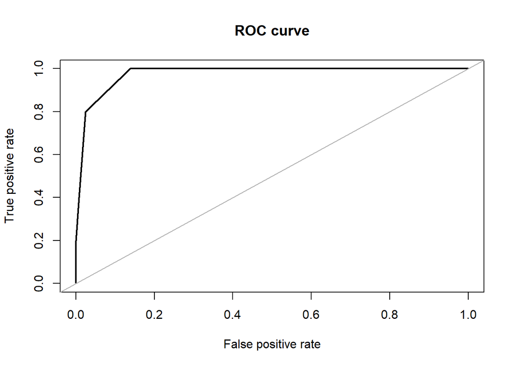

```
## Area under the curve (AUC): 0.976
```

```r
#AUC smote
roc.curve(hacide.test$cls, pred.tree.smote[,2])
```